# R Notebook

Here we present the R notebook for the solutions of Homework 4

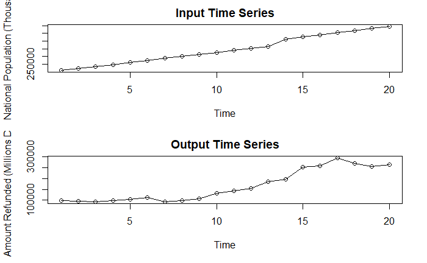

```r
df_6.18<-read.csv("B20.csv", header = TRUE)
x_t_6.18<-df_6.18[,3]
y_t_6.18<-df_6.18[,2]
x_t_6.18.ts<-ts(x_t_6.18)
y_t_6.18.ts<-ts(y_t_6.18)
par(mfrow=c(2,1), oma=c(0,0,0,0))
plot(x_t_6.18.ts, type="o", xlab="Time", ylab="National Population (Thousands)", main="Input Time Series")
plot(y_t_6.18.ts, type="o", xlab="Time", ylab = "Amount Refunded (Millions Dollars)", main = "Output Time Series")
```

Plotting the Cross corrilation function CCF

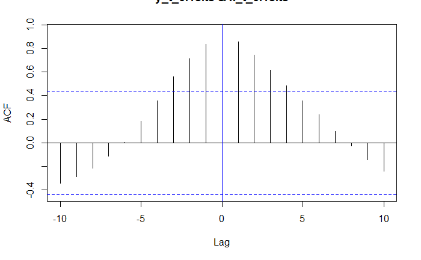

```r
ccf(y_t_6.18.ts, x_t_6.18.ts)
abline(v=0, col="blue")
```

The input and output time series seem to be cross correlated. Now let’s plot the input time series ACF and PACF

```r
par(mfrow=c(1,2), oma=c(0,0,0,0))
acf(x_t_6.18.ts, type = "correlation", main="ACF for National Population")
acf(x_t_6.18.ts, type = "partial", main="PACF for National Population")
```

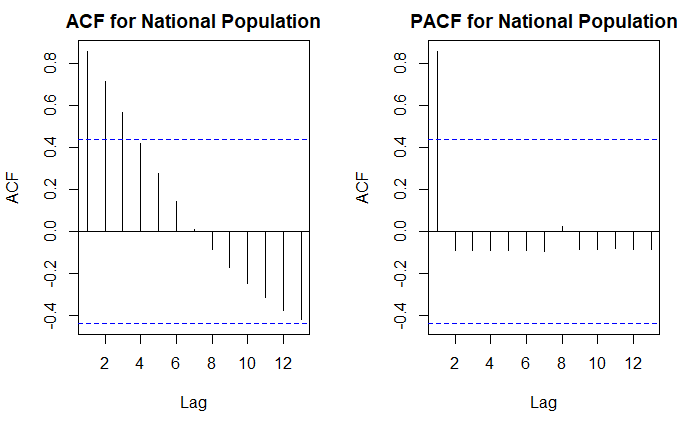

```r
par(mfrow=c(1,2), oma=c(0,0,0,0))
```

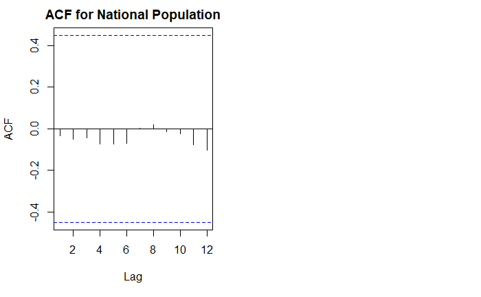

```r
acf(diff(x_t_6.18.ts), type = "correlation", main="ACF for National Population")
acf(diff(x_t_6.18.ts), type = "partial", main="PACF for National Population")
```

```r
x_t_6.18.ts.AR1<-arima(x_t_6.18.ts, order = c(1,0,0))
arima(x_t_6.18.ts, order = c(1,1,0))
```

```
Call:
arima(x = x_t_6.18.ts, order = c(1, 1, 0))

Coefficients:
         ar1
      0.7600
s.e.  0.1365

sigma^2 estimated as 4508442:  log likelihood = -172.94,  aic = 347.89
```

```r
#x_t_6.18.ts.IMA<-arima(x_t_6.18.ts, order = c(0,1,1))
#x_t_6.18.ts.IMA
x_t_6.18.ts.AR1
```

```
Call:
arima(x = x_t_6.18.ts, order = c(1, 0, 0))

Coefficients:
         ar1  intercept
      0.9923  270589.91
s.e.  0.0108   26310.85

sigma^2 estimated as 11318627:  log likelihood = -192.89,  aic = 389.78
```

```r
res.x_t_6.18.ts<-as.vector(residuals(x_t_6.18.ts.AR1))
fit.x_t_6.18.ts<-as.vector(fitted(x_t_6.18.ts.AR1))
par(mfrow=c(1,2), oma=c(0,0,0,0))
acf(res.x_t_6.18.ts, lag.max = 25, type="correlation", main="ACF of the Residuals for x(t)")
acf(res.x_t_6.18.ts, lag.max = 25, type="partial", main="PACF of the Residuals for x(t)")
```

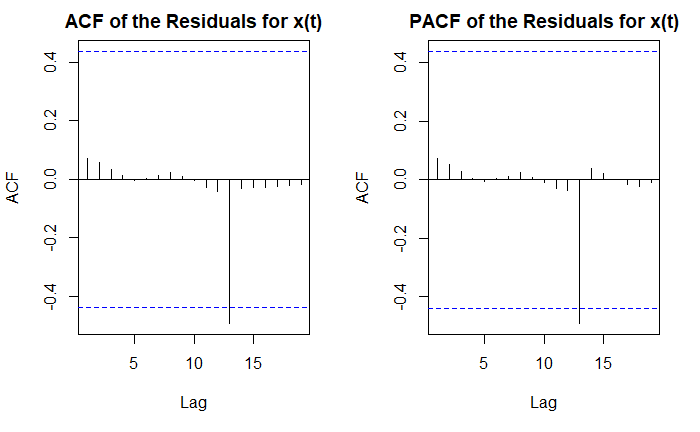

```r
par(mfrow=c(2,2), oma=c(0,0,0,0))
```

```r
qqnorm(res.x_t_6.18.ts, datax=TRUE, pch=16, xlab="Residual", main="")
qqline(res.x_t_6.18.ts, datax=TRUE)
```

```r
plot(fit.x_t_6.18.ts, res.x_t_6.18.ts, pch=16, xlab="Fitted value", ylab="Residual")
abline(h=0)
```

```r
hist(res.x_t_6.18.ts, col="gray", xlab="Residual", main="")
plot(res.x_t_6.18.ts, type="l", xlab="Observation order", ylab="Residual")
```

```r
points(res.x_t_6.18.ts, pch=16, cex=0.5)
abline(h=0)
```

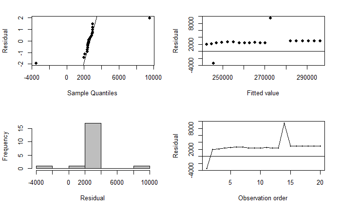

```r
res.x_t_6.18.ts<-as.vector(residuals(x_t_6.18.ts.IMA))
fit.x_t_6.18.ts<-as.vector(fitted(x_t_6.18.ts.IMA))
par(mfrow=c(1,2), oma=c(0,0,0,0))
```

```r
acf(res.x_t_6.18.ts, lag.max = 25, type="correlation", main="ACF of the Residuals for x(t)")
acf(res.x_t_6.18.ts, lag.max = 25, type="partial", main="PACF of the Residuals for x(t)")
```

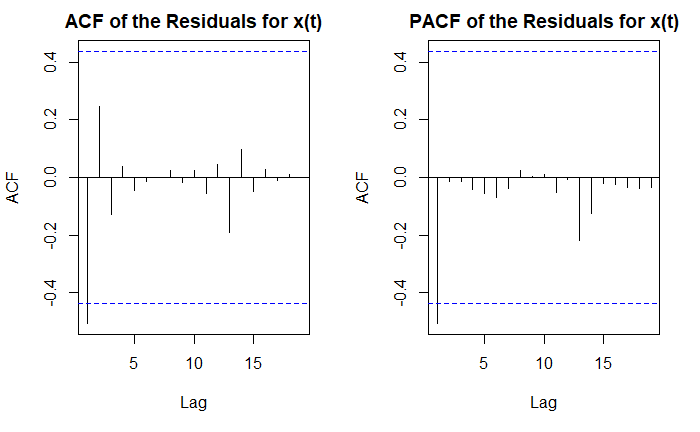

```r
par(mfrow=c(2,2), oma=c(0,0,0,0))
```

```r
qqnorm(res.x_t_6.18.ts, datax=TRUE, pch=16, xlab="Residual", main="")
qqline(res.x_t_6.18.ts, datax=TRUE)
```

```r
plot(fit.x_t_6.18.ts, res.x_t_6.18.ts, pch=16, xlab="Fitted value", ylab="Residual")
abline(h=0)
```

```r
hist(res.x_t_6.18.ts, col="gray", xlab="Residual", main="")
plot(res.x_t_6.18.ts, type="l", xlab="Observation order", ylab="Residual")
```

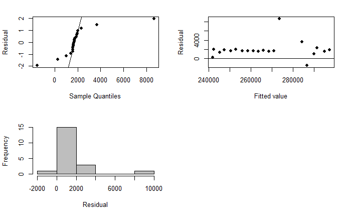

```r
points(res.x_t_6.18.ts, pch=16, cex=0.5)
abline(h=0)
```

It seems pretty good, but it does have a couple of outliers. As can be seen from the time series plot as well.

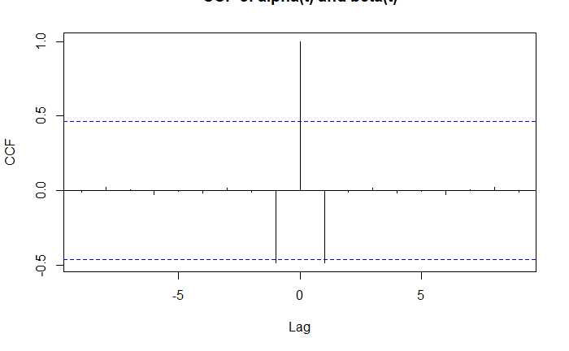

```r
T<-length(x_t_6.18.ts)
#alpha_t<-diff(x_t_6.18.ts)[2:T]-0.76*diff(x_t_6.18.ts)[1:(T-1)]
alpha_t<-x_t_6.18.ts[3:T]-1.76*x_t_6.18.ts[2:(T-1)]+0.76*x_t_6.18.ts[1:(T-2)]
beta_t<-x_t_6.18.ts[3:T]-1.76*x_t_6.18.ts[2:(T-1)]+0.76*x_t_6.18.ts[1:(T-2)]
#beta_t<-diff(y_t_6.18.ts)[2:T]-0.76*diff(y_t_6.18.ts)[1:(T-1)]
ralbe<-ccf(beta_t, alpha_t, main = "CCF of alpha(t) and beta(t)", ylab="CCF")
```

```r
#abline(v=0, col="blue")
```

Obtaining the estimates of v_t

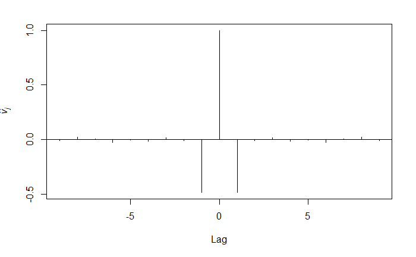

```r
v_hat<-sqrt(var(beta_t)/var(alpha_t))*ralbe$acf
n1<-length(v_hat)
plot(seq(-(n1-1)/2, (n1-1)/2,1), v_hat, type = 'h', xlab = 'Lag', ylab = expression(italic(hat(v)[italic(j)])))
#abline(v=0, col='blue')
abline(h=0)
```

```r
v0<-v_hat[10]
v1<-v_hat[11]
```

Now to model the noise

```r
N_hat<-array(0, dim = c(1,T))
for(i in 2:T){
  N_hat[i]<-y_t_6.18.ts[i]-v0*x_t_6.18.ts[i]-v1*x_t_6.18.ts[i-1]
}
N_hat<-N_hat[3:T]
N_hat
```

```
 [1] -35353.819 -30837.544 -27527.614 -20380.476 -41274.719 -39091.732 -29286.486  -5844.017
 [9]   2659.352  12655.900  42854.585  44999.148 103700.254 107085.328 144027.085 117430.058
[17] 100576.074 107272.061
```

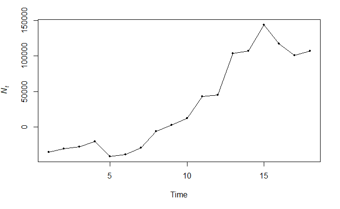

```r
plot(N_hat, type="o", pch=16, cex=.5, xlab="Time", ylab=expression(italic(hat(N)[italic(t)])))
par(mfrow=c(1,2), oma=c(0,0,0,0))
```

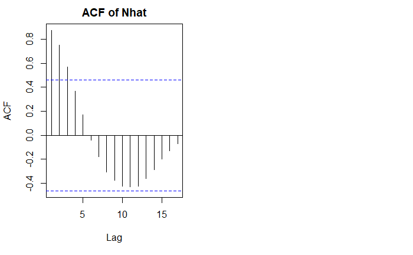

```r
acf(N_hat, lag.max=25, type="correlation", main="ACF of Nhat")
acf(N_hat, lag.max=25, type="partial", main="PACF of Nhat")
```

It seems that N_hat can be modeled as an AR(1) or AR(2)

```r
N_hat.ar1<-arima(N_hat, order = c(1,1,0), include.mean = FALSE)
auto.arima(N_hat)
```

```
Series: N_hat
ARIMA(0,1,0) with drift

Coefficients:
         drift
      8389.758
s.e.  4893.311

sigma^2 estimated as 432495700:  log likelihood=-192.63
AIC=389.26   AICc=390.12   BIC=390.93
```

```r
res.N_hat.ar1<-as.vector(residuals(N_hat.ar1))
fit.N_hat.ar1<-as.vector(fitted(N_hat.ar1))
par(mfrow=c(1,2), oma=c(0,0,0,0))
acf(res.N_hat.ar1, lag.max = 25, type="correlation", main="ACF of the Residuals for N_hat")
acf(res.N_hat.ar1, lag.max = 25, type="partial", main="PACF of the Residuals for N_hat")
```

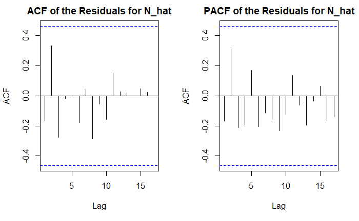

```r
par(mfrow=c(2,2), oma=c(0,0,0,0))
```

```r
qqnorm(res.N_hat.ar1, datax=TRUE, pch=16, xlab="Residual", main="")
qqline(res.N_hat.ar1, datax=TRUE)
```

```r
plot(fit.N_hat.ar1, res.N_hat.ar1, pch=16, xlab="Fitted value", ylab="Residual")
abline(h=0)
```

```r
hist(res.N_hat.ar1, col="gray", xlab="Residual", main="")
plot(res.N_hat.ar1, type="l", xlab="Observation order", ylab="Residual")
```

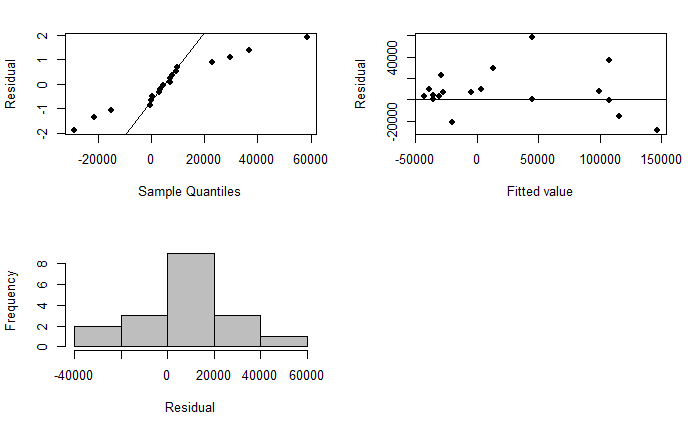

```r
points(res.N_hat.ar1, pch=16, cex=0.5)
abline(h=0)
```

Using the arimax funtion in TSA

```r
lag1.x_t_6.18.ts<-lag(x_t_6.18.ts,0)
dat1<-cbind(x_t_6.18.ts, lag1.x_t_6.18.ts, y_t_6.18.ts)
dimnames(dat1)[[2]]<-c("xt","lag1x","yt")
data2<-na.omit(as.data.frame(dat1))
data2
```

|  | xt | lag1x | yt |
| --- | --- | --- | --- |
| 1 | 242289 | 242289 | 96969 |
| 2 | 244499 | 244499 | 94480 |
| 3 | 246819 | 246819 | 93613 |
| 4 | 249464 | 249464 | 99656 |
| 5 | 252153 | 252153 | 104380 |
| 6 | 255030 | 255030 | 113108 |
| 7 | 257783 | 257783 | 93580 |
| 8 | 260327 | 260327 | 96980 |
| 9 | 262803 | 262803 | 108035 |
| 10 | 265229 | 265229 | 132710 |

[output cut: 10 more lines]

```r
#Input arguments
#order: determines the model for the error component, i.e. the order of the
#ARIMA model for y(t) if there were no x(t)
#xtrans:x(t)
#transfer: the orders (r and s) of the trasfer function
tf.6.18<-arimax(data2$yt, order=c(1,1,0), xtransf = data.frame(data2$lag1x), transfer=list(c(0,1)), include.mean = FALSE)
tf.6.18
```

```
Call:
arimax(x = data2$yt, order = c(1, 1, 0), include.mean = FALSE, xtransf = data.frame(data2$lag1x),
    transfer = list(c(0, 1)))

Coefficients:
         ar1  data2.lag1x-MA0  data2.lag1x-MA1
      0.1043          -1.6294           5.2551
s.e.  0.2377           1.7829           1.7912

sigma^2 estimated as 2.68e+08:  log likelihood = -200.21,  aic = 406.41
```

```r
#ARIMAX.6.18.1<-arimax(y_t_6.18.ts, order = c(1,0,0), transfer = list(c(0,1)))
```

Model adquecy check

```r
res.tf.6.18<-na.omit(as.vector(residuals(tf.6.18)))
fit.tf.6.18<-na.omit(as.vector(fitted(tf.6.18)))
par(mfrow=c(1,2), oma=c(0,0,0,0))
acf(res.tf.6.18, lag.max = 25, type="correlation", main="ACF of the Residuals for TF-N Model")
acf(res.tf.6.18, lag.max = 25, type="partial", main="PACF of the Residuals for TF-N Model")
```

```r
fit.tf.6.18
```

```
 [1]  95260.38 102266.01 100587.55 108982.45 113323.10 123666.59 100756.15 105592.57 117273.15
[10] 142924.60 152146.87 162985.47 184982.86 242303.21 264654.00 267492.45 309463.46 277439.54
[19] 262835.67
attr(,"na.action")
[1] 1
attr(,"class")
[1] "omit"
```

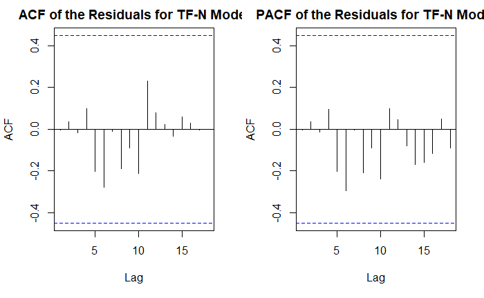

```r
par(mfrow=c(2,2), oma=c(0,0,0,0))
```

```r
qqnorm(res.tf.6.18, datax=TRUE, pch=16, xlab="Residual", main="")
qqline(res.tf.6.18, datax=TRUE)
```

```r
plot(fit.tf.6.18, res.tf.6.18, pch=16, xlab="Fitted value", ylab="Residual")
abline(h=0)
```

```r
hist(res.tf.6.18, col="gray", xlab="Residual", main="")
plot(res.tf.6.18, type="l", xlab="Observation order", ylab="Residual")
```

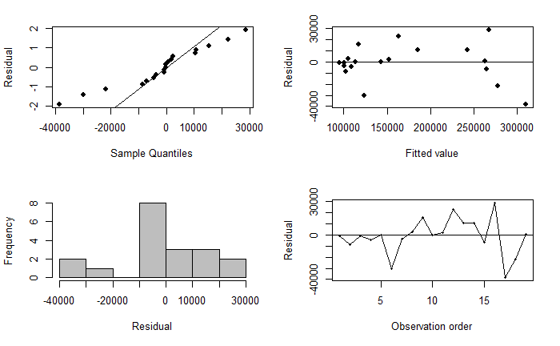

```r
points(res.tf.6.18, pch=16, cex=0.5)
abline(h=0)
```

```r
T<-length(res.tf.6.18)
T
```

```
[1] 19
```

```r
Ta<-length(alpha_t)+1
Ta
```

```
[1] 19
```

```r
res.tf.6.18
```

```
 [1]   -780.3847  -8653.0064   -931.5469  -4602.4535   -215.1037 -30086.5854  -3776.1450
 [8]   2442.4309  15436.8532   -325.5988   1681.1295  22296.5349  10768.1391  10483.7891
[15]  -7010.0025  28571.5517 -38570.4591 -22000.5360    665.3331
attr(,"na.action")
[1] 1
attr(,"class")
[1] "omit"
```

```r
alpha_t
```

```
 [1]   640.40   881.80   678.80   833.36   566.48   451.72   542.56   544.24   711.24   522.20
[11]   570.36  7645.32 -4306.52   661.60   678.48   629.60   619.68   600.72
```

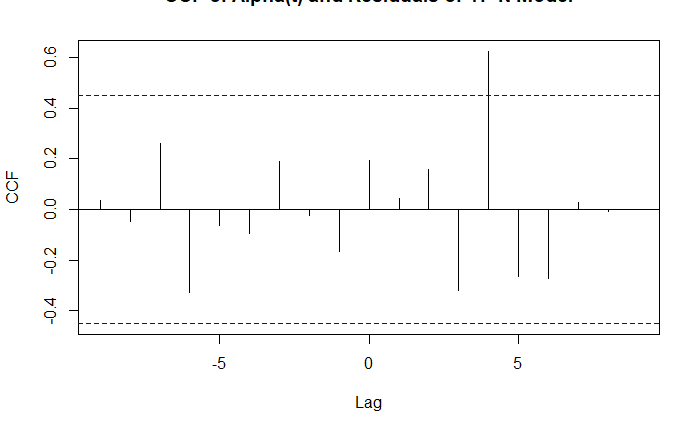

```r
ccf(res.tf.6.18, alpha_t[(Ta-T+1):Ta], main = "CCF of Alpha(t) and Residuals of TF-N Model", ylab = "CCF",  na.action = na.pass)
```

Problem 6.16

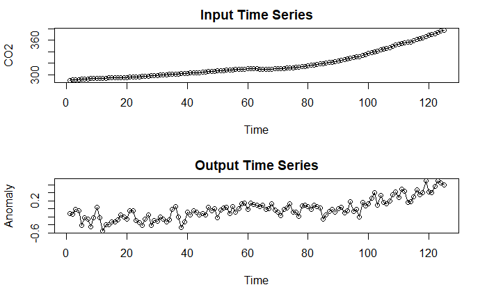

```r
df_6.16<-read.csv("B6.csv", header = TRUE)
x_t_6.16.ts<-ts(df_6.16[,3])
y_t_6.16.ts<-ts(df_6.16[,2])
par(mfrow=c(2,1), oma=c(0,0,0,0))
plot(x_t_6.16.ts, type="o", xlab="Time", ylab="CO2", main="Input Time Series")
plot(y_t_6.16.ts, type="o", xlab="Time", ylab = "Anomaly", main = "Output Time Series")
```

Plotting the cross correlation between input and output

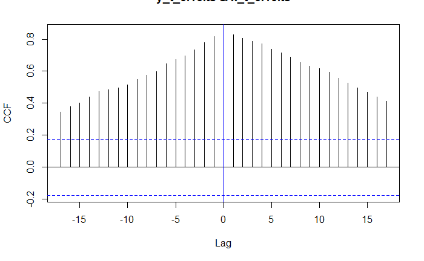

```r
ccf(y_t_6.16.ts, x_t_6.16.ts, ylab="CCF")
abline(v=0, col="blue")
```

The two series do seem to be extremely cross correlated. Now, let’s plot the ACF and PACF of the input time series

```r
par(mfrow=c(1,2), oma=c(0,0,0,0))
acf(x_t_6.16.ts, type = "correlation", main="ACF for National Population")
acf(x_t_6.16.ts, type = "partial", main="PACF for National Population")
```

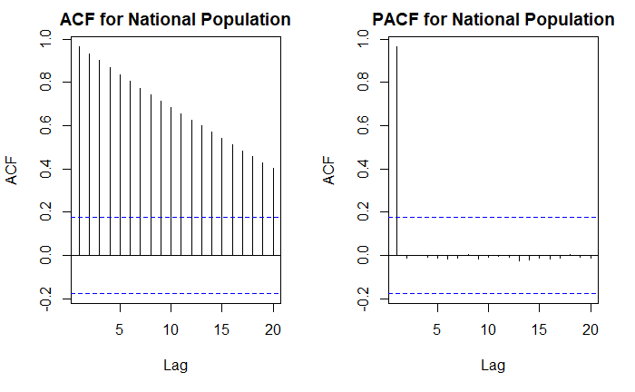

```r
par(mfrow=c(1,2), oma=c(0,0,0,0))
```

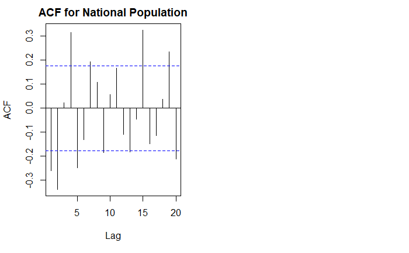

```r
acf(diff(diff(x_t_6.16.ts)), type = "correlation", main="ACF for National Population")
acf(diff(diff(x_t_6.16.ts)), type = "partial", main="PACF for National Population")
```

```r
x_t_6.16.ts.AR1<-arima(x_t_6.16.ts, order = c(1,2,0))
x_t_6.16.ts.AR1
```

```
Call:
arima(x = x_t_6.16.ts, order = c(1, 2, 0))

Coefficients:
          ar1
      -0.2663
s.e.   0.0881

sigma^2 estimated as 0.1057:  log likelihood = -36.35,  aic = 74.7
```

```r
#auto.arima(x_t_6.16.ts)
#x_t_6.16.ts.AR32<-arima(x_t_6.16.ts, order = c(3,2,0))
```

For the prewhitening we will use the ARIMA(1,2,0) model. Checking model adequecy

```r
res.x_t_6.16.ts<-as.vector(residuals(x_t_6.16.ts.AR1))
fit.x_t_6.16.ts<-as.vector(fitted(x_t_6.16.ts.AR1))
par(mfrow=c(1,2), oma=c(0,0,0,0))
acf(res.x_t_6.16.ts, lag.max = 25, type="correlation", main="ACF of the Residuals for x(t)")
acf(res.x_t_6.16.ts, lag.max = 25, type="partial", main="PACF of the Residuals for x(t)")
```

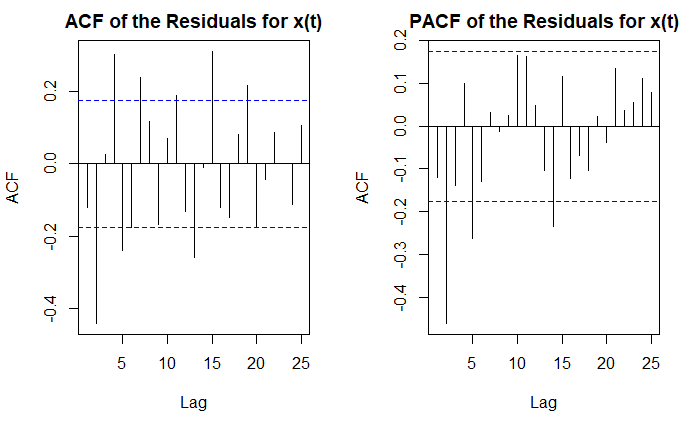

```r
par(mfrow=c(2,2), oma=c(0,0,0,0))
```

```r
qqnorm(res.x_t_6.16.ts, datax=TRUE, pch=16, xlab="Residual", main="")
qqline(res.x_t_6.16.ts, datax=TRUE)
```

```r
plot(fit.x_t_6.16.ts, res.x_t_6.16.ts, pch=16, xlab="Fitted value", ylab="Residual")
abline(h=0)
```

```r
hist(res.x_t_6.16.ts, col="gray", xlab="Residual", main="")
plot(res.x_t_6.16.ts, type="l", xlab="Observation order", ylab="Residual")
```

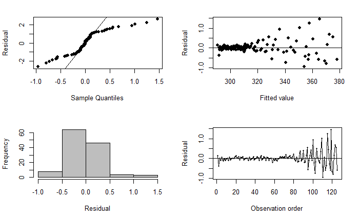

```r
points(res.x_t_6.16.ts, pch=16, cex=0.5)
abline(h=0)
```

Let’s prewhiten

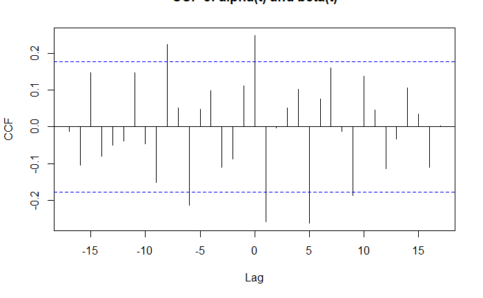

```r
T<-length(x_t_6.16.ts)
alpha_t<-x_t_6.16.ts[4:T]-1.7337*x_t_6.16.ts[3:(T-1)]+0.4674*x_t_6.16.ts[2:(T-2)]+0.2663*x_t_6.16.ts[1:(T-3)]
beta_t<-y_t_6.16.ts[4:T]-1.7337*y_t_6.16.ts[3:(T-1)]+0.4674*y_t_6.16.ts[2:(T-2)]+0.2663*y_t_6.16.ts[1:(T-3)]
ralbe<-ccf(beta_t, alpha_t, main = "CCF of alpha(t) and beta(t)", ylab="CCF")
```

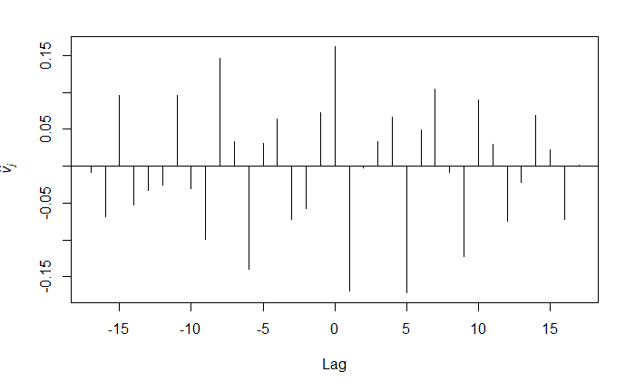

```r
#abline(v=0, col="blue")
vhat<-sqrt(var(beta_t)/var(alpha_t))*ralbe$acf
nl<-length(vhat)
plot(seq(-(nl-1)/2, (nl-1)/2, 1), vhat, type="h", xlab="Lag", ylab=expression(italic(hat(v)[italic(j)])))
#abline(v=0, col="blue")
abline(h=0)
```

```r
v0<-vhat[18]
v1<-vhat[19]
v2<-vhat[20]
v3<-vhat[21]
v4<-vhat[22]
v5<-vhat[23]
```

Creation of N_hat and analyzing N_hat for the selectio of its model

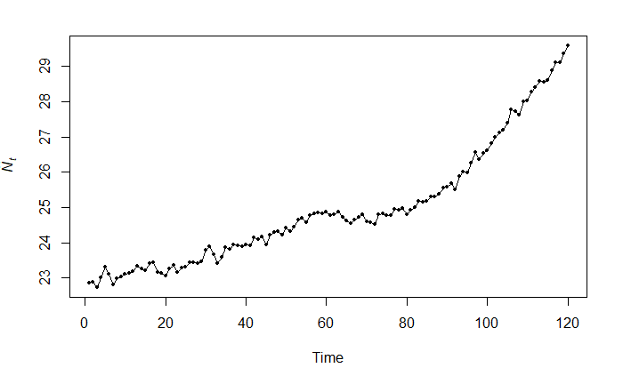

```r
N_hat<-array(0, dim = c(1,T))
for(i in 6:T){
  N_hat[i]<-y_t_6.16.ts[i]-v0*x_t_6.16.ts[i]-v1*x_t_6.16.ts[i-1]-v2*x_t_6.16.ts[i-2]-v3*x_t_6.16.ts[i-3]-v4*x_t_6.16.ts[i-4]-v5*x_t_6.16.ts[i-5]
}
N_hat<-N_hat[6:T]
plot(N_hat, type="o", pch=16, cex=.5, xlab="Time", ylab=expression(italic(hat(N)[italic(t)])))
par(mfrow=c(1,2), oma=c(0,0,0,0))
```

```r
acf(N_hat, lag.max=25, type="correlation", main="ACF of Nhat")
acf(N_hat, lag.max=25, type="partial", main="PACF of Nhat")
```

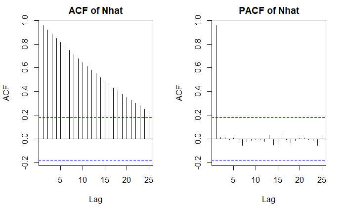

```r
par(mfrow=c(1,2), oma=c(0,0,0,0))
```

```r
acf(diff(N_hat), lag.max=25, type="correlation", main="ACF of Nhat")
acf(diff(N_hat), lag.max=25, type="partial", main="PACF of Nhat")
```

```r
auto.arima(N_hat)
```

```
Series: N_hat
ARIMA(3,2,3)

Coefficients:
          ar1      ar2      ar3      ma1      ma2     ma3
      -0.6915  -0.1695  -0.3919  -0.5276  -0.7137  0.4412
s.e.   0.1545   0.1884   0.0970   0.1603   0.1223  0.1421

sigma^2 estimated as 0.01719:  log likelihood=73.77
AIC=-133.54   AICc=-132.52   BIC=-114.15
```

```r
arima(N_hat, order = c(0,1,0))
```

```
Call:
arima(x = N_hat, order = c(0, 1, 0))


sigma^2 estimated as 0.0248:  log likelihood = 51.12,  aic = -102.23
```

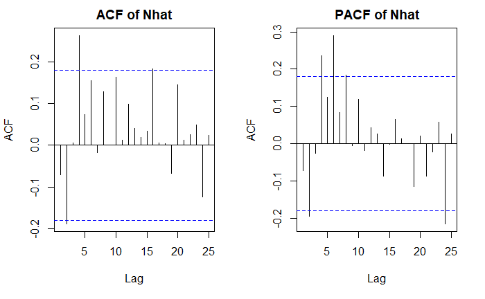

```r
par(mfrow=c(1,2), oma=c(0,0,0,0))
```

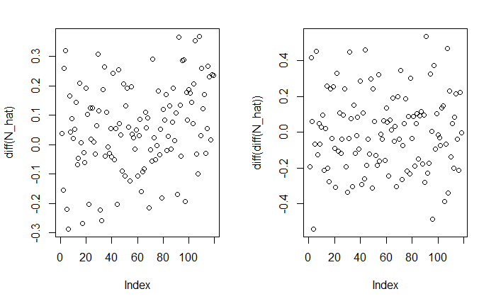

```r
plot(diff(N_hat))
plot(diff(diff(N_hat)))
```

By using the auto.arima function we can see that N_hat is best modeled with an ARIMA(3,2,3). Now let’s create the final model

```r
lag0.x<-lag(x_t_6.16.ts, 0)
dat0<-cbind.data.frame(x_t_6.16.ts, lag0.x, y_t_6.16.ts)
dimnames(dat0)[[2]]<-c("xt","lag0x", "yt")
data2<-na.omit(as.data.frame(dat0))
tf1.6.16<-arimax(data2$yt, order=c(1,2,0), xtransf = data.frame(data2$lag0x), transfer = list(c(1,0)), include.mean = FALSE)
tf1.6.16
```

```
Call:
arimax(x = data2$yt, order = c(1, 2, 0), include.mean = FALSE, xtransf = data.frame(data2$lag0x),
    transfer = list(c(1, 0)))

Coefficients:
          ar1  data2.lag0x-AR1  data2.lag0x-MA0
      -0.4847          -0.0021           0.1356
s.e.   0.0786           0.0052           0.0544

sigma^2 estimated as 0.03995:  log likelihood = 23.37,  aic = -40.74
```

```r
tf2.6.16<-arimax(data2$yt, order=c(2,2,0), xtransf = data.frame(data2$lag0x), transfer = list(c(1,0)), include.mean = FALSE)
```

```
possible convergence problem: optim gave code=1
```

```r
tf2.6.16
```

```
Call:
arimax(x = data2$yt, order = c(2, 2, 0), include.mean = FALSE, xtransf = data.frame(data2$lag0x),
    transfer = list(c(1, 0)))

Coefficients:
          ar1      ar2  data2.lag0x-AR1  data2.lag0x-MA0
      -0.7089  -0.4378           0.0036           0.0959
s.e.   0.0818   0.0823           0.0069           0.0526

sigma^2 estimated as 0.03258:  log likelihood = 35.7,  aic = -63.4
```

```r
tf3.6.16<-arimax(data2$yt, order=c(3,2,0), xtransf = data.frame(data2$lag0x), transfer = list(c(1,0)), include.mean = FALSE)
tf3.6.16
```

```
Call:
arimax(x = data2$yt, order = c(3, 2, 0), include.mean = FALSE, xtransf = data.frame(data2$lag0x),
    transfer = list(c(1, 0)))

Coefficients:
          ar1      ar2      ar3  data2.lag0x-AR1  data2.lag0x-MA0
      -0.9249  -0.8073  -0.5249          -0.0007           0.1438
s.e.   0.0776   0.0887   0.0788           0.0038           0.0453

sigma^2 estimated as 0.02362:  log likelihood = 54.99,  aic = -99.97
```

```r
tf4.6.16<-arimax(data2$yt, order=c(3,2,3), xtransf = data.frame(data2$lag0x), transfer = list(c(1,0)), include.mean = FALSE)
tf4.6.16
```

```
Call:
arimax(x = data2$yt, order = c(3, 2, 3), include.mean = FALSE, xtransf = data.frame(data2$lag0x),
    transfer = list(c(1, 0)))

Coefficients:
          ar1      ar2      ar3      ma1      ma2     ma3  data2.lag0x-AR1  data2.lag0x-MA0
      -0.6099  -0.0674  -0.3197  -0.9462  -0.6831  0.6294          -0.0363           0.0156
s.e.   0.1399   0.1454   0.0962   0.1396   0.1956  0.1258           0.0301           0.0046

sigma^2 estimated as 0.01435:  log likelihood = 81.93,  aic = -147.87
```

Model adequacy

```r
res.tf.6.16<-na.omit(as.vector(residuals(tf4.6.16)))
fit.tf.6.16<-na.omit(as.vector(fitted(tf4.6.16)))
par(mfrow=c(1,2), oma=c(0,0,0,0))
acf(res.tf.6.16, lag.max = 25, type="correlation", main="ACF of the Residuals for TF-N Model")
acf(res.tf.6.16, lag.max = 25, type="partial", main="PACF of the Residuals for TF-N Model")
```

```r
fit.tf.6.16
```

```
  [1] -1.079246e-01 -1.365312e-01  5.303492e-03  5.299326e-02 -1.239866e-01 -3.346920e-01
  [7] -1.979108e-01 -2.755896e-01 -4.532820e-01 -2.135368e-01 -1.618324e-01 -3.435153e-01
 [13] -4.555246e-01 -3.033704e-01 -3.846038e-01 -3.873405e-01 -3.867732e-01 -3.677740e-01
 [19] -2.865347e-01 -3.295527e-01 -2.971328e-01 -1.690793e-01 -1.872612e-01 -2.952384e-01
 [25] -2.444764e-01 -2.787895e-01 -2.224873e-01 -2.161461e-01 -3.762938e-01 -2.602267e-01
 [31] -2.817739e-01 -2.714789e-01 -2.767573e-01 -3.311919e-01 -2.551585e-01 -1.673322e-01
 [37] -1.488190e-01 -2.748709e-01 -2.930061e-01 -1.972109e-01 -1.317786e-01 -2.353056e-01
 [43] -1.495303e-01 -1.612896e-01 -1.805167e-01 -1.085615e-01 -1.447698e-01 -4.285155e-02
 [49] -9.933094e-02 -6.001836e-02 -1.246649e-01 -3.267472e-02  1.147042e-02 -5.857356e-02
 [55] -4.941752e-02  6.967411e-03 -2.227544e-02 -2.369439e-02  8.372049e-02  1.414776e-02
 [61]  6.194273e-03  7.608398e-02  8.952016e-02  3.464303e-02  8.740546e-02  6.454650e-02
 [67]  5.321251e-02  3.724651e-02  1.200955e-01 -1.127952e-02  1.249609e-02 -2.593188e-02
 [73]  3.536894e-02  1.979683e-02  3.382464e-02 -4.178433e-02 -1.790335e-02 -2.411426e-02
 [79]  5.144852e-02  5.708044e-02 -1.441740e-02  4.266224e-02  7.481767e-02  7.456013e-02
 [85]  3.156607e-02 -3.612969e-02  4.515037e-03  5.074667e-02 -2.584637e-02 -8.554949e-03
 [91] -2.458014e-05  4.963835e-02 -5.546968e-02  4.363358e-02  1.116681e-01 -1.838285e-02
 [97]  3.108529e-02 -3.427016e-03  1.261193e-01  1.007625e-01  6.788211e-02  2.395664e-01
[103]  2.101314e-01  1.629844e-01  2.916906e-01  2.679802e-01  1.935792e-01  3.386912e-01
[109]  3.179139e-01  3.914261e-01  2.755099e-01  4.720140e-01  3.895770e-01  2.890716e-01
[115]  3.739763e-01  4.276917e-01  4.400343e-01  3.798910e-01  4.413217e-01  6.091559e-01
[121]  4.217509e-01  4.948548e-01  6.181578e-01  6.321000e-01  6.290824e-01
```

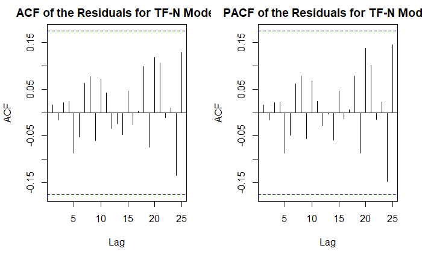

```r
par(mfrow=c(2,2), oma=c(0,0,0,0))
```

```r
qqnorm(res.tf.6.16, datax=TRUE, pch=16, xlab="Residual", main="")
qqline(res.tf.6.16, datax=TRUE)
```

```r
plot(fit.tf.6.16, res.tf.6.16, pch=16, xlab="Fitted value", ylab="Residual")
abline(h=0)
```

```r
hist(res.tf.6.16, col="gray", xlab="Residual", main="")
plot(res.tf.6.16, type="l", xlab="Observation order", ylab="Residual")
```

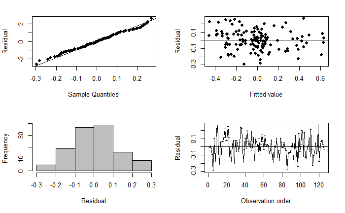

```r
points(res.tf.6.16, pch=16, cex=0.5)
abline(h=0)
```

```r
T<-length(res.tf.6.16)
T
```

```
[1] 125
```

```r
Ta<-length(alpha_t)+3
Ta
```

```
[1] 125
```

```r
res.tf.6.16
```

```
  [1] -0.002075373  0.006531207 -0.015303492 -0.092993259 -0.296013367  0.104692009 -0.052089191
  [8] -0.174410373  0.223281955  0.253536769 -0.058167648 -0.206484658  0.055524618 -0.086629561
 [15]  0.064603789  0.067340548  0.116773234  0.217773998  0.076534668  0.079552731  0.247132755
 [22]  0.119079317 -0.112738816 -0.054761562 -0.175523554  0.028789519  0.072487296 -0.193853940
 [29]  0.076293800 -0.049773273  0.071773945  0.021478931 -0.053242662  0.051191911  0.235158527
 [36]  0.227332180 -0.051180994 -0.185129069 -0.036993866  0.107210907 -0.018221367  0.195305572
 [43]  0.059530256  0.001289614  0.070516745 -0.041438470  0.184769831 -0.007148454  0.109330937
 [50] -0.159981641  0.094664916  0.062674723  0.028529584 -0.051426439  0.099417515 -0.086967411
 [57]  0.032275439  0.143694395  0.066279511 -0.034147758  0.133805727  0.033916019  0.010479835
 [64]  0.025356974  0.012594540 -0.074546497 -0.043212509  0.082753494 -0.150095495 -0.078720478
 [71] -0.182496089  0.005931883 -0.005368943  0.100203173 -0.123824644 -0.048215674 -0.162096649
 [78]  0.104114263  0.048551482 -0.007080444 -0.005582603  0.057337759 -0.024817670 -0.044560131
 [85] -0.281566066 -0.113870313 -0.074515037 -0.070746666 -0.064153631  0.008554949  0.040024580
 [92] -0.149638347  0.005469683  0.136366422 -0.171668128 -0.001617146 -0.241085293  0.163427016
 [99] -0.056119263  0.029237452  0.202117891  0.160433628 -0.110131449  0.177015629 -0.131690581
[106] -0.137980169 -0.003579188  0.011308841  0.102086090 -0.111426094  0.214490149 -0.032014003
[113] -0.229576991 -0.109071632 -0.063976314  0.042308291 -0.080034326  0.020108971  0.268678261
[120] -0.179155916 -0.011750942  0.065145206  0.081842215  0.027899997 -0.029082367
```

```r
alpha_t
```

```
  [1] -1.000000e-01  7.337000e-02 -7.337000e-02 -1.266300e-01 -2.663000e-02 -1.000000e-01
  [7] -2.663000e-02 -1.421085e-14 -1.000000e-01  7.337000e-02 -7.337000e-02 -2.663000e-02
 [13]  4.263256e-14 -4.263256e-14  1.421085e-14  1.000000e-01  1.266300e-01  2.663000e-02
 [19] -4.263256e-14  1.000000e-01 -7.337000e-02  7.337000e-02  2.663000e-02  1.000000e-01
 [25] -7.337000e-02 -2.663000e-02  8.526513e-14 -9.947598e-14  4.263256e-14 -1.000000e-01
 [31]  7.337000e-02 -7.337000e-02 -2.663000e-02  5.684342e-14  1.000000e-01 -7.337000e-02
 [37] -2.663000e-02  2.842171e-14  1.000000e-01  2.663000e-02 -1.000000e-01  7.337000e-02
 [43]  1.266300e-01 -7.337000e-02 -2.663000e-02  1.000000e-01  2.663000e-02 -1.000000e-01
 [49]  7.337000e-02  2.663000e-02 -1.000000e-01 -2.663000e-02 -2.842171e-14  1.136868e-13
 [55] -2.000000e-01 -5.326000e-02 -1.000000e-01 -2.663000e-02 -1.000000e-01 -1.266300e-01
 [61] -2.663000e-02  5.684342e-14  1.000000e-01  2.663000e-02  1.000000e-01  2.663000e-02
 [67]  1.000000e-01  2.663000e-02  2.000000e-01  5.326000e-02 -2.842171e-14  1.000000e-01
 [73]  1.266300e-01  2.663000e-02 -1.136868e-13  1.000000e-01  2.266300e-01 -4.674000e-02
 [79] -1.266300e-01  7.337000e-02 -1.733700e-01 -1.532600e-01  2.733700e-01  3.798900e-01
 [85] -1.201100e-01 -5.326000e-02  4.000000e-01 -1.934800e-01 -1.798900e-01  1.733700e-01
 [91]  5.532600e-01 -5.668500e-01 -8.641000e-02  1.266300e-01  4.266300e-01 -9.348000e-02
 [97]  9.467400e-01 -2.337000e-01 -7.331500e-01 -1.597800e-01  5.000000e-01  3.315000e-02
[103] -1.266300e-01 -2.266300e-01  3.467400e-01  1.006520e+00 -9.603300e-01 -4.195600e-01
[109]  7.337000e-02 -5.733700e-01 -3.597800e-01  1.246740e+00  4.461900e-01 -2.733700e-01
[115] -5.798900e-01  1.466850e+00 -6.739200e-01 -7.929300e-01  1.668500e-01  6.798900e-01
[121]  5.597800e-01 -5.934800e-01
```